# GWAS and GEA

Anoob Prakash

14/04/2020

# Trait data

## Combined

```r
finalHeight <- read.csv("C:/Dropbox/Spruce_CommonGarden_Data/trait_data/final_ht_2019.csv")
nrow(finalHeight) # 5177
```

```
## [1] 5177
```

```r
initialHeight <- read.csv("C:/Dropbox/Spruce_CommonGarden_Data/trait_data/initialHt.csv")
nrow(initialHeight) #5048
```

```
## [1] 5048
```

```r
BudSet <- read.csv("C:/Dropbox/Spruce_CommonGarden_Data/trait_data/BudSet2019_december.csv")
nrow(BudSet) # 5085
```

```
## [1] 5085
```

```r
heightData <- merge(initialHeight,finalHeight,
                    all.x = TRUE, all.y = TRUE)
heightData <- merge(heightData, BudSet,
                    all.x = T)
heightData <- heightData[unique(heightData$plant_ID),]
nrow(heightData)
```

```
## [1] 5190
```

```r
nrow(heightData)
```

```
## [1] 5190
```

```r
heightData <- heightData[unique(heightData$plant_ID),]
nrow(heightData) #5190
```

```
## [1] 4544
```

```r
tdata <- heightData

require(tidyr)
# modifying longitude
tdata <- tdata %>% dplyr::mutate(Longitude, mLongitude = Longitude * -1)

# adding garden IDs to the beds
tdata <- tdata %>% tidyr::unite(mBed, Garden, Bed, sep = "_", remove = FALSE)

# converting to factors
tdata$mBed <- as.factor(tdata$mBed)


# reordering factors
tdata$Region <- factor(tdata$Region,
                       levels = c("C", "M", "E"))

tdata$Garden <- factor(tdata$Garden,
                       levels = c("VT", "MD", "NC"))


# rearraging and renaming the dataframe
tdata <- tdata[,c(1:5,10,9,11:16,18,20,22,17,19,21,8,23,6)]
names(tdata)[18] <- "final_ht"
names(tdata)[15] <- "final_ht_notes"
names(tdata)[21] <- "lon"
names(tdata)[22] <- "lat"
tdata$Growth <- tdata$final_ht - tdata$initial_ht
```

## Height growth

```r
finalHeight <- read.csv("C:/Dropbox/Spruce_CommonGarden_Data/trait_data/final_ht_2019.csv")
nrow(finalHeight) # 5177
```

```
## [1] 5177
```

```r
initialHeight <- read.csv("C:/Dropbox/Spruce_CommonGarden_Data/trait_data/initialHt.csv")
nrow(initialHeight) #5048
```

```
## [1] 5048
```

```r
heightData <- merge(initialHeight,finalHeight,
                    all.x = TRUE, all.y = TRUE)

heightData <- heightData[unique(heightData$plant_ID),]
nrow(heightData)
```

```
## [1] 5190
```

```r
ht_data <- heightData

# modifying longitude
ht_data$Longitude <- ht_data$Longitude * -1

# adding garden IDs to the beds
ht_data <- ht_data %>% tidyr::unite(mBed, Garden, Bed, sep = "_", remove = FALSE)

# converting to factors
ht_data$mBed <- as.factor(ht_data$mBed)

# reordering factors
ht_data$Region <- factor(ht_data$Region,
                         levels = c("C", "M", "E"))

ht_data$Garden <- factor(ht_data$Garden,
                         levels = c("VT", "MD", "NC"))


# rearraging and renaming the dataframe
ht_data <- ht_data[,c(1:5,10,9,11:16,18,20,17,19,7,6,8)]
names(ht_data)[17] <- "final_ht"
names(ht_data)[15] <- "final_ht_notes"
names(ht_data)[18] <- "lon"
names(ht_data)[19] <- "lat"
ht_data$Growth <- ht_data$final_ht - ht_data$initial_ht

ht_data <- ht_data[!is.na(ht_data$final_ht),]
ht_data <- ht_data[!is.na(ht_data$initial_ht),]
```

## Bud set

```r
BudSet <- read.csv("C:/Dropbox/Spruce_CommonGarden_Data/trait_data/BudSet2019_december.csv")
nrow(BudSet) # 5085
```

```
## [1] 5085
```

```r
require(tidyr)
# modifying longitude
BudSet <- BudSet %>% dplyr::mutate(Longitude, mLongitude = Longitude * -1)

# adding garden IDs to the beds
BudSet <- BudSet %>% tidyr::unite(mBed, Garden, Bed, sep = "_", remove = FALSE)

# converting to factors
BudSet$mBed <- as.factor(BudSet$mBed)


# reordering factors
BudSet$Region <- factor(BudSet$Region,
                       levels = c("C", "M", "E"))

BudSet$Garden <- factor(BudSet$Garden,
                       levels = c("VT", "MD", "NC"))


# rearraging and renaming the dataframe
budset_dat <- BudSet[,c(1:5,10,9,11:18,19,6,8)]
names(budset_dat)[16] <- "lon"
names(budset_dat)[17] <- "lat"
```

# Troubleshooting pipeline

## Defining variables

blups for the edge region family located on the server:  
/data/project_data/RS_ExomeSeq/ANGSD/blups/Ht_EDGE_MD.blups

**Setting file locations**

```bash
# location of family blups for height trait
blups="/data/project_data/RS_ExomeSeq/ANGSD/blups"

# location of the PC score files files
PC="/data/project_data/RS_ExomeSeq/ANGSD"

# output folder - also location of bam file lists
OUT="/data/project_data/GroupProjects/GWAS_env/"

# Location of the reference genome
REF="/data/project_data/RS_ExomeSeq/ReferenceGenomes/Pabies1.0-genome_reduced.fa"

## breaking into contigs to look at a smaller subset at a time
contigs="/data/project_data/RS_ExomeSeq/ANGSD/contig_splits"
mycontigs="xaa"
```

**Make a list of .bam files**

```bash
ls /data/project_data/RS_ExomeSeq/mapping/all/*final.bam >${OUT}/bam/all/all_bam.list
```

grep  
- source: https://www.howtogeek.com/496056/how-to-use-the-grep-command-on-linux/  
- Regex in grep: https://linuxize.com/post/regular-expressions-in-grep/  
- linux manual: http://linuxcommand.org/lc3_man_pages/grep1.html

```bash
# pull inds from meta data that belong to edge pops

cat /data/project_data/RS_ExomeSeq/metadata/RS_Exome_metadata.txt | grep -w "E" | cut -f1 | uniq >${OUT}/edge_ind.txt

# -w      : match the whole word
# -v      : invert match; opposite of -w
# cut -f1 : cut the first column
# uniq    : only uniques are selected

## match the edge inds with bam list to create edge_bam.list

ls /data/project_data/RS_ExomeSeq/mapping/all/*final.bam | grep -f ${OUT}/edge_ind.txt | uniq >${OUT}/bam/edge/edge_bam.list

# -f : match pattern from a file
```

## GWAS Edge-subsetted

```bash
ANGSD -b ${OUT}/bam/edge/edge_bam.list \
-ref ${REF} \
-out ${OUT}/ANGSD/GWAS/GWAS_HT_Edge_sub/Ht_EDGE_MD_PC12_${mycontigs} \
-remove_bads 1 \
-C 50 \
-baq 1 \
-minMapQ 20 \
-minQ 20 \
-setMinDepth 3 \
-minInd 2 \
-setMinDepthInd 1 \
-setMaxDepthInd 17 \
-skipTriallelic 1 \
-GL 1 \
-doPost 1 \
-doCounts 1 \
-doMajorMinor 1 \
-doMaf 1 \
-SNP_pval 1e-6 \
-yQuant ${blups}/Ht_EDGE_MD.blups \
-doAsso 5 \
-rf ${contigs}/${mycontigs} \
-cov ${PC}/PCA/EDGE_PC12.txt
```

## GWAS Edge

```bash
ANGSD -b ${OUT}/bam/edge/edge_bam.list \
-ref ${REF} \
-out ${OUT}/ANGSD/GWAS/GWAS_HT_Edge/Ht_EDGE_MD_PC12 \
-remove_bads 1 \
-C 50 \
-baq 1 \
-minMapQ 20 \
-minQ 20 \
-setMinDepth 3 \
-minInd 2 \
-setMinDepthInd 1 \
-setMaxDepthInd 17 \
-skipTriallelic 1 \
-GL 1 \
-doPost 1 \
-doCounts 1 \
-doMajorMinor 1 \
-doMaf 1 \
-SNP_pval 1e-6 \
-yQuant ${blups}/Ht_EDGE_MD.blups \
-doAsso 5 \
-cov ${PC}/PCA/EDGE_PC12.txt
```

## Beagle and PCangsd

```bash
## beagle
cd /data/project_data/GroupProjects/GWAS_env/bam/edge/

ANGSD -GL 2 -out edge -nThreads 1 -doGlf 2 -doMajorMinor 1 -doMaf 1 -SNP_pval 1e-6 -bam edge_bam.list

# change python s/w env to v3
scl enable rh-python36 bash

## PCA angsd
python pcangsd.py -beagle edge.beagle.gz -admix -o edge_PC -threads 1



ANGSD -beagle edge.beagle.gz -admix -out edge_PC -threads 1 -fai
```

# Blups

```r
require(tidyr)
require(lme4)
```

## Height growth

```r
# ht_data <--- cleaned data for height growth

ht_mod1 <- lmer(data = ht_data,
               Growth ~ Garden +
               (1|Family) + (1|mBed))

ht_mod2 <- lmer(data = ht_data,
               Growth ~ Garden +
               (1|Family))

AIC(ht_mod1, ht_mod2)
```

```
##         df      AIC
## ht_mod1  6 26115.18
## ht_mod2  5 26358.27
```

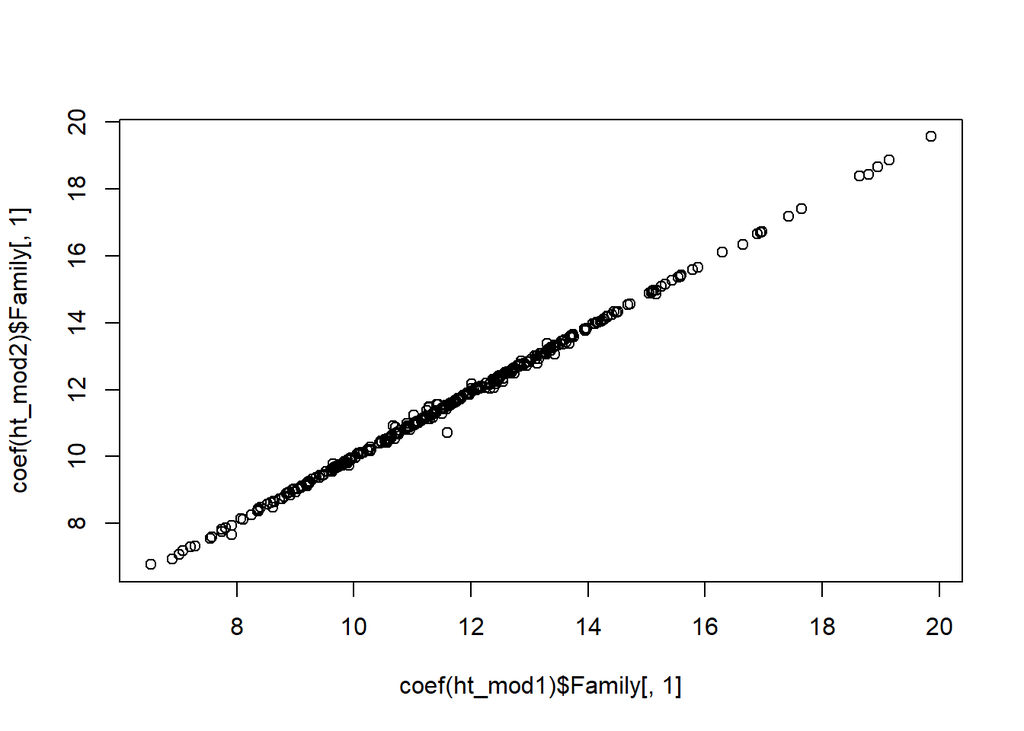

```r
plot(coef(ht_mod1)$Family[,1], coef(ht_mod2)$Family[,1])
```

```r
# setting up blups for height growth
coef_ht <- coef(ht_mod1) # nrow = 368
head(coef_ht[[1]][,1]) # family coefficients
```

```
## [1]  9.815585 10.587683 12.698083 11.775678 11.942354  9.712639
```

```r
ranef_ht <- ranef(ht_mod1)
head(ranef_ht[[1]][,1]) # family slope
```

```
## [1] -1.8599643 -1.0878666  1.0225337  0.1001283  0.2668043 -1.9629106
```

```r
blups_ht <- cbind(ranef_ht$Family,coef_ht$Family$`(Intercept)`)
names(blups_ht)[1] <- "ranef"
names(blups_ht)[2] <- "blups"
head(blups_ht)
```

```
##            ranef     blups
## AB_01 -1.8599643  9.815585
## AB_02 -1.0878666 10.587683
## AB_03  1.0225337 12.698083
## AB_04  0.1001283 11.775678
## AB_05  0.2668043 11.942354
## AB_06 -1.9629106  9.712639
```

```r
blups <- blups_ht %>% dplyr::select(blups)
blups <- cbind(Family=rownames(blups),blups) # add family id based on row names
rownames(blups) <- NULL # remove row names

# write.csv(blups,"./blups/blups_edge_trial.txt", row.names = TRUE)


# read in the bam files
all.bam <- read.table("./bam.files/all_bam.list", stringsAsFactors =F)
all.bam <- as.data.frame(all.bam)
head(all.bam)
```

```
##                                                                                                          V1
## 1  /home/Anoob/mydata/datashare/Spruce/exome_capture/WES_mapping/Mapping_WES/ref_Pabies/BWA/AB_05.final.bam
## 2  /home/Anoob/mydata/datashare/Spruce/exome_capture/WES_mapping/Mapping_WES/ref_Pabies/BWA/AB_08.final.bam
## 3  /home/Anoob/mydata/datashare/Spruce/exome_capture/WES_mapping/Mapping_WES/ref_Pabies/BWA/AB_12.final.bam
## 4  /home/Anoob/mydata/datashare/Spruce/exome_capture/WES_mapping/Mapping_WES/ref_Pabies/BWA/AB_16.final.bam
## 5  /home/Anoob/mydata/datashare/Spruce/exome_capture/WES_mapping/Mapping_WES/ref_Pabies/BWA/AB_18.final.bam
## 6 /home/Anoob/mydata/datashare/Spruce/exome_capture/WES_mapping/Mapping_WES/ref_Pabies/BWA/ALB_01.final.bam
```

```r
names(all.bam)[1] <- "path"

all.bam$Family <- gsub("/home/Anoob/mydata/datashare/Spruce/exome_capture/WES_mapping/Mapping_WES/ref_Pabies/BWA/","",
                       all.bam$path)
all.bam$Family <- gsub(".final.bam","",all.bam$Family)

# filter out blups for families absent in the bam file

blups_ht <- merge(all.bam, blups,
                 by="Family", all.x=TRUE)
blups_ht <- na.omit(blups_ht)
str(blups_ht) # 307 blups and bam file paths
```

```
## 'data.frame':    307 obs. of  3 variables:
##  $ Family: chr  "AB_05" "AB_08" "AB_12" "AB_16" ...
##  $ path  : chr  "/home/Anoob/mydata/datashare/Spruce/exome_capture/WES_mapping/Mapping_WES/ref_Pabies/BWA/AB_05.final.bam" "/home/Anoob/mydata/datashare/Spruce/exome_capture/WES_mapping/Mapping_WES/ref_Pabies/BWA/AB_08.final.bam" "/home/Anoob/mydata/datashare/Spruce/exome_capture/WES_mapping/Mapp…
##  $ blups : num  11.9 12.8 10.7 13.6 11.3 ...
##  - attr(*, "na.action")= 'omit' Named int  257 309 310 311 312 313 314 315 316 317 ...
##   ..- attr(*, "names")= chr  "257" "309" "310" "311" ...
```

```r
head(blups_ht[3])
```

```
##      blups
## 1 11.94235
## 2 12.82501
## 3 10.73624
## 4 13.55927
## 5 11.28864
## 6 12.48629
```

**Write out bam list and blups for height growth**

```r
# write bam file list
# dest <- file("./bam.files/ht_bam.list", open="wb")
# write.table(blups_ht[,2], file=dest,col.names = FALSE,
#             row.names = FALSE, sep="",quote = FALSE, eol = "\n")
# close(dest) # required to close the file connection
#
#
# # write blups
# dest <- file("./blups/wright server/ht_blups", open="wb")
# write.table(blups_ht[,3], file=dest,col.names = FALSE,
#             row.names = FALSE, sep=" ",quote = FALSE, eol = "\n")
# close(dest)
```

## Bud set

```r
# budset_dat <--- cleaned data for bud set

# lmer for budset
budset_mod1 <- lmer(data = budset_dat,
                     BudSet ~ Garden +
                     (1|Family) + (1|mBed))

# setting up the blups for budset
coef_budset <- coef(budset_mod1) # blups
head(coef_budset[[1]][,1]) # family coefficients
```

```
## [1] 266.1273 271.1599 264.6810 260.9723 272.0779 276.2823
```

```r
ranef_budset <- ranef(budset_mod1)
head(ranef_budset[[1]][,1]) # random effects
```

```
## [1] -1.857712  3.174821 -3.304098 -7.012775  4.092804  8.297221
```

```r
blups_budset <- cbind(ranef_budset$Family,coef_budset$Family$`(Intercept)`)
names(blups_budset)[1] <- "ranef"
names(blups_budset)[2] <- "blups"
head(blups_budset)
```

```
##           ranef    blups
## AB_01 -1.857712 266.1273
## AB_02  3.174821 271.1599
## AB_03 -3.304098 264.6810
## AB_04 -7.012775 260.9723
## AB_05  4.092804 272.0779
## AB_06  8.297221 276.2823
```

```r
blups_budset <- blups_budset %>% dplyr::select(blups)
blups_budset <- cbind(Family=rownames(blups_budset),blups_budset) # add family id based on row names
rownames(blups_budset) <- NULL # remove row names

### code for bam list on the ecogen server
# write.csv(blups,"./blups/blups_edge_trial.txt", row.names = TRUE)


# read in the bam files
# all.bam <- read.table("./bam.files/all_bam.list", stringsAsFactors =F)
# all.bam <- as.data.frame(all.bam)
# head(all.bam)
# names(all.bam)[1] <- "path"
#
# all.bam$Family <- gsub("/data/project_data/RS_ExomeSeq/mapping/all/","",
#                        all.bam$path)
# all.bam$Family <- gsub(".final.bam","",all.bam$Family)
####


# filter out blups for families absent in the bam file
blups_bs <- merge(all.bam, blups_budset,
                 by="Family", all.x=TRUE)
blups_bs <- na.omit(blups_bs)
str(blups_bs) # 339 blups and bam file paths
```

```
## 'data.frame':    339 obs. of  3 variables:
##  $ Family: chr  "AB_05" "AB_08" "AB_12" "AB_16" ...
##  $ path  : chr  "/home/Anoob/mydata/datashare/Spruce/exome_capture/WES_mapping/Mapping_WES/ref_Pabies/BWA/AB_05.final.bam" "/home/Anoob/mydata/datashare/Spruce/exome_capture/WES_mapping/Mapping_WES/ref_Pabies/BWA/AB_08.final.bam" "/home/Anoob/mydata/datashare/Spruce/exome_capture/WES_mapping/Mapp…
##  $ blups : num  272 276 272 272 266 ...
##  - attr(*, "na.action")= 'omit' Named int 257
##   ..- attr(*, "names")= chr "257"
```

```r
tail(blups_bs[3])
```

```
##        blups
## 335 267.5754
## 336 259.9682
## 337 246.6324
## 338 270.2424
## 339 265.1306
## 340 251.9035
```

**Write out bam list and blups for budset**

```r
# # write bam file list
# dest <- file("./bam.files/bs_bam.list", open="wb")
# write.table(blups_bs[,2], file=dest,col.names = FALSE,
#             row.names = FALSE, sep="",quote = FALSE, eol = "\n")
# close(dest) # required to close the file connection
#
#
# # write blups
# dest <- file("./blups/wright server/bs_blups", open="wb")
# write.table(blups_bs[,3], file=dest,col.names = FALSE,
#             row.names = FALSE, sep=" ",quote = FALSE, eol = "\n")
# close(dest)
```

## bioclim variables

```r
meta <- read.table("./mydata/metadata/RS_Exome_metadata.txt", sep="\t",header = T)
meta <- meta[,c(3,5,7,8,9)]
meta$Longitude <- meta$Longitude * -1
```

```r
require(tidyr)
require(raster)
```

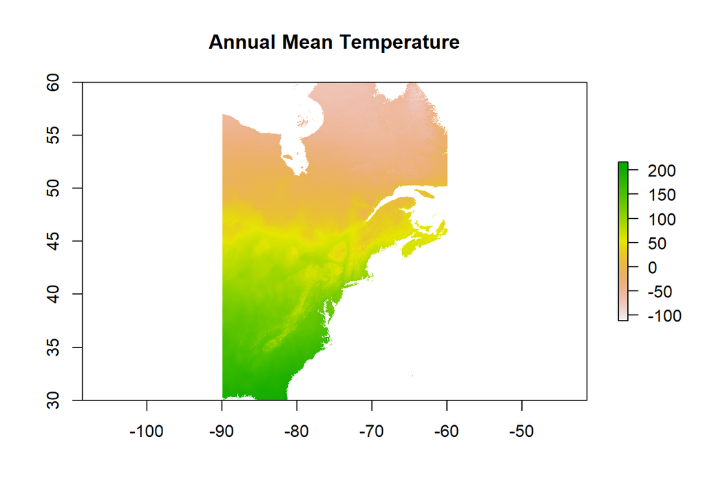

```r
### bioclim variables for provenances and sites
bio_prov <- raster::getData("worldclim",var="bio",res=0.5,
                         lon=-80, lat=50,
                         download = TRUE,
                         path = "D:/worldclim data/0.5/")

#bio1 - mean annual temp
#bio12 - annual precipitation

#Plot
plot(bio_prov$bio1_13, main="Annual Mean Temperature")
```

```r
bio_prov@crs # to check the projection system # crs(bio_prov) - does the same function
```

```
## CRS arguments:
##  +proj=longlat +datum=WGS84 +ellps=WGS84 +towgs84=0,0,0
```

```r
# points <- SpatialPoints(tdata[,c(22,23)], proj4string = bio_prov@crs)
nrow(meta)
```

```
## [1] 340
```

```r
tdata <- meta[!is.na(meta$Latitude),]
nrow(tdata)
```

```
## [1] 340
```

```r
bioT <- raster::extract(bio_prov,
                        coordinates(tdata[,c("Longitude","Latitude")]))

# df <- cbind.data.frame(coordinates(points),values)

head(bioT)
```

```
##      bio1_13 bio2_13 bio3_13 bio4_13 bio5_13 bio6_13 bio7_13 bio8_13 bio9_13
## [1,]      70     104      34    7058     214     -85     299      68     122
## [2,]      70     104      34    7058     214     -85     299      68     122
## [3,]      79     110      36    7021     226     -78     304      77     131
## [4,]      79     110      36    7021     226     -78     304      77     131
## [5,]      79     110      36    7021     226     -78     304      77     131
## [6,]      46     120      29    9718     243    -160     403       0     -72
##      bio10_13 bio11_13 bio12_13 bio13_13 bio14_13 bio15_13 bio16_13 bio17_13
## [1,]      158      -24     2006      197      143        7      537      463
## [2,]      158      -24     2006      197      143        7      537      463
## [3,]      166      -15     1923      191      134        8      516      439
## [4,]      166      -15     1923      191      134        8      516      439
## [5,]      166      -15     1923      191      134        8      516      439
## [6,]      167      -85     1237      129       85       11      347      270
##      bio18_13 bio19_13
## [1,]      509      492
## [2,]      509      492
## [3,]      487      478
## [4,]      487      478
## [5,]      487      478
## [6,]      319      284
```

```r
trait_df_biol_all <- cbind(tdata,bioT)
```

**Bioclims used in the transcriptomics study**  
- Bio18 (precip of warmest quarter)  
- Bio5 (temp of warmest month)  
- Bio10 (temp of the warmest quarter)

```r
bio18 <- trait_df_biol_all$bio18_13
bio05 <- trait_df_biol_all$bio5_13
bio10 <- trait_df_biol_all$bio10_13
```

**Write out files**

```r
# # write bio18
# dest <- file("./blups/wright server/bio18", open="wb")
# write.table(bio18, file=dest,col.names = FALSE,
#             row.names = FALSE, sep=" ",quote = FALSE, eol = "\n")
# close(dest)
#
# # write bio05
# dest <- file("./blups/wright server/bio05", open="wb")
# write.table(bio05, file=dest,col.names = FALSE,
#             row.names = FALSE, sep=" ",quote = FALSE, eol = "\n")
# close(dest)
# # write bio10
# dest <- file("./blups/wright server/bio10", open="wb")
# write.table(bio10, file=dest,col.names = FALSE,
#             row.names = FALSE, sep=" ",quote = FALSE, eol = "\n")
# close(dest)
```

# Defining variables

blups for the edge region family located on the server:  
/data/project_data/RS_ExomeSeq/ANGSD/blups/Ht_EDGE_MD.blups

**Setting file locations** 1. Wright

```bash
# bam files location on wright
~/mydata/datashare/Spruce/exome_capture/WES_mapping/Mapping_WES/ref_Pabies/BWA

# create bam list
ls ~/mydata/datashare/Spruce/exome_capture/WES_mapping/Mapping_WES/ref_Pabies/BWA/*final.bam >/home/Anoob/mydata/Anoob/ANGSD/bam/all_bam.list
```

2. Ecogen server

```bash
# location of the PC score files files
PC="/data/project_data/GroupProjects/GWAS_env/PCA/"

# output folder - also location of bam file lists
OUT="/data/project_data/GroupProjects/GWAS_env/"

# Location of the reference genome
REF="/data/project_data/RS_ExomeSeq/ReferenceGenomes/Pabies1.0-genome_reduced.fa"

## breaking into contigs to look at a smaller subset at a time
contigs="/data/project_data/RS_ExomeSeq/ANGSD/contig_splits"
mycontigs="xaa"
```

**Make a list of .bam files**

```bash
ls /data/project_data/RS_ExomeSeq/mapping/all/*final.bam >${OUT}/bam/all/all_bam.list
```

# PCA

## beagle (Wright server)

```bash
# check error Killed
ANGSD -b ${OUT}/bam/all/all_bam.list

# beagle output for env vars
angsd -GL 1 \
-out /home/Anoob/mydata/Anoob/ANGSD/beagle/all \
-nThreads 3 \
-doGlf 2 \
-doMajorMinor 1 \
-doMaf 1 \
-SNP_pval 1e-6 \
-bam /home/Anoob/mydata/Anoob/ANGSD/bam/all_bam.list \
-C 50 \
-baq 1 \
-minMapQ 20 \
-minQ 20 \
-setMinDepth 2 \
-doCounts 1 \
-minInd 20 \
-setMinDepthInd 1 \
-setMaxDepthInd 17 \
-skipTriallelic 1 \
-ref ~/mydata/datashare/Spruce/exome_capture/WES_mapping/ReferenceGenomes/Pabies1.0-genome_reduced.fa

# beagle output without relevant filters (Pbio Server)
ANGSD -GL 1 \
-out ${OUT}/ANGSD/beagle/all/all_beagle \
-nThreads 1 \
-doGlf 2 \
-doMajorMinor 1 \
-doMaf 1 \
-SNP_pval 1e-6 \
-bam ${OUT}/bam/all/all_bam.list
```

## PCAngsd (EcoGen server)

```bash
# set python env in the server to 3.0
scl enable rh-python36 bash

# check python version
python -V  # version 3.6.9

## PC ANGSD for all beagle files

python /data/popgen/pcangsd/pcangsd.py \
-beagle /data/project_data/GroupProjects/GWAS_env/ANGSD/beagle/all/all.beagle.gz \
-admix \
-admix_auto 3 \
-o /data/project_data/GroupProjects/GWAS_env/PCA/pcangsd/all_PC \
-threads 5

# without admix
python /data/popgen/pcangsd/pcangsd.py \
-beagle /data/project_data/GroupProjects/GWAS_env/ANGSD/beagle/all/all.beagle.gz \
-o /data/project_data/GroupProjects/GWAS_env/PCA/pcangsd/all_Noadmix \
-threads 5
```

## PC scores

```r
# install.packages('RcppCNPy')
# install.packages('label.switching')

library(RcppCNPy)
library(tidyverse)
library(ggfortify)
```

**PC scores**  
Zoe:  
- To summarize what I did, I imported the covariance matrix (the .cov file) and the admixture results (the .npy file). - I made a quick and dirty barplot of the admixture results. The individuals are just in the same order as how they are in the .npy file so I suppose that’s just the same order as the bam file list.  
- I performed PCA on the covariance matrix using prcomp() and then scaled it using the stdev. I’ll send the plot but I think that will be more helpful for all the pops put together (we can compare with Thibaut’s plot…).  
- Last, I wrote the scaled PCs to a txt file without col or row names. I didn’t mess with the order at all, so hopefully it’s in the order it’s supposed to be!!

```r
# reads results from admixure
edge <-npyLoad('./PCA/all_PC.admix.Q.npy')
edge <- as.data.frame(edge)
edge

bp = barplot(t(as.matrix(edge)),
             space = c(0.2),
             col=rainbow(2),
             xlab="Individual #",
             ylab="Ancestry",
             border=NA)

# reads estimated covariance matrix
cov <- as.matrix(read.table("./PCA/all_PC.cov"))
# compute eigenvalues and eigenvectors
cov.eigen <- eigen(cov)

plot(cov.eigen$values, xlab = 'Eigenvalue Number', ylab = 'Eigenvalue Size', main = 'Scree Graph')
lines(cov.eigen$values)

# Perform PCA on covariance matrix
edge.pca <- prcomp(cov)
edge.pca
summary(edge.pca)

# plot unscaled PCs
pca.plot <- autoplot(edge.pca, data = edge)
pca.plot

# scaling
scaling <- edge.pca$sdev[1:2] * sqrt(nrow(edge))

pc1 <- rowSums(t(t(sweep(edge, 2 ,colMeans(edge))) *cov.eigen$vectors[,1] * -1) / scaling[1])
pc2 <- rowSums(t(t(sweep(edge, 2, colMeans(edge))) *cov.eigen$vectors[,2]) / scaling[2])

# collect PCs in data.frame and plot
df <- data.frame(pc1, pc2)

ggplot(df, aes(x=pc1, y=pc2)) +
  geom_point()


# subset for budset phenotype
famlist <- all.bam$Family
famlist <- cbind(famlist,df)
names(famlist)[1] <- "Family"
bslist <-  na.omit(blups_bs)
str(bslist)
bslist <- merge(bslist,famlist, by="Family")
bs_df <- data.frame(bslist[,c(4,5)])

# subset for height phenotype
famlist <- all.bam$Family
famlist <- cbind(famlist,df)
names(famlist)[1] <- "Family"
htlist <-  na.omit(blups_ht)
str(htlist)
htlist <- merge(htlist,famlist, by="Family")
ht_df <- data.frame(htlist[,c(4,5)])
```

**Write out files**

```r
# # save df without row or column names for GWAS - all
# write.table(df, "./PCA/scores/all.txt",
#             row.names = F, col.names = F)
#
# # save df without row or column names for GWAS - budset
# write.table(bs_df, "./PCA/scores/bc_PC.txt",
#             row.names = F, col.names = F)
#
# # save df without row or column names for GWAS - height
# write.table(ht_df, "./PCA/scores/ht_PC.txt",
#             row.names = F, col.names = F)
```

# GWAS

## Filter details

```bash
# notes: https://github.com/mfumagalli/ngsTools/blob/master/TUTORIAL.md

ANGSD -b ${OUT}/bam/edge/edge_budset_bam.list \
-ref ${REF} \
-out ${OUT}/ANGSD/GWAS/GWAS_BS_Edge/budset_EDGE_MD_PC12 \
-remove_bads 1 \     # Discard 'bad' reads, (flag >=256)
-C 50 \              # adjust mapQ for excessive mismatches (as SAMtools), supply -ref
-baq 1 \             # adjust qscores around indels (as SAMtools), supply -ref
-minMapQ 20 \        # Discard reads with mapping quality below
-minQ 20 \           # Discard bases with base quality below
-setMinDepth 2 \     # minimum total depth
-minInd 20 \          # use only sites with data from at least 2 individuals
-setMinDepthInd 1 \
-setMaxDepthInd 17 \
-skipTriallelic 1 \
-GL 1 \              # Estimate genotype likelihoods
<!-- -doPost 1 \ -->
-doCounts 1 \        # Calculate various counts statistics
-doMajorMinor 1 \    # Infer the major/minor using different approaches
-doMaf 1 \           # Estimate allele frequencies
-SNP_pval 1e-6 \     # Remove sites with a pvalue larger
-yQuant ${OUT}/blups/edge_budset_blups.list \
-doAsso 5 \
-cov ${OUT}/PCA/edge.txt
```

## Bud set

```bash
angsd -b /home/Anoob/mydata/Anoob/ANGSD/bam/bs_bam.list \
-ref ~/mydata/datashare/Spruce/exome_capture/WES_mapping/ReferenceGenomes/Pabies1.0-genome_reduced.fa \
-out /home/Anoob/mydata/Anoob/ANGSD/GWAS/budset2019/budset \
-remove_bads 1 \
-C 50 \
-baq 1 \
-minMapQ 20 \
-minQ 20 \
-setMinDepth 2 \
-minInd 20 \
-setMinDepthInd 1 \
-setMaxDepthInd 17 \
-skipTriallelic 1 \
-GL 1 \
-doPost 1 \
-doCounts 1 \
-doMajorMinor 1 \
-doMaf 1 \
-SNP_pval 1e-6 \
-yQuant /home/Anoob/mydata/Anoob/ANGSD/blups/bs_blups \
-doAsso 5 \
-nThreads 4 \
-cov /home/Anoob/mydata/Anoob/ANGSD/beagle/PC_scores/bc_PC.txt
```

## Height growth

```bash
angsd -b /home/Anoob/mydata/Anoob/ANGSD/bam/ht_bam.list \
-ref ~/mydata/datashare/Spruce/exome_capture/WES_mapping/ReferenceGenomes/Pabies1.0-genome_reduced.fa \
-out /home/Anoob/mydata/Anoob/ANGSD/GWAS/height2019/height \
-remove_bads 1 \
-C 50 \
-baq 1 \
-minMapQ 20 \
-minQ 20 \
-setMinDepth 2 \
-minInd 20 \
-setMinDepthInd 1 \
-setMaxDepthInd 17 \
-skipTriallelic 1 \
-GL 1 \
-doPost 1 \
-doCounts 1 \
-doMajorMinor 1 \
-doMaf 1 \
-SNP_pval 1e-6 \
-yQuant /home/Anoob/mydata/Anoob/ANGSD/blups/ht_blups \
-doAsso 5 \
-nThreads 4 \
-cov /home/Anoob/mydata/Anoob/ANGSD/beagle/PC_scores/ht_PC.txt
```

## Height growth (Pbio server)

```bash
ANGSD -b ${OUT}/bam/edge/edge_bam.list \
-ref ${REF} \
-out ${OUT}/ANGSD/GWAS/GWAS_HT_Edge/Ht_EDGE_MD_PC12 \
-remove_bads 1 \
-C 50 \
-baq 1 \
-minMapQ 20 \
-minQ 20 \
-setMinDepth 3 \
-minInd 2 \
-setMinDepthInd 1 \
-setMaxDepthInd 17 \
-skipTriallelic 1 \
-GL 1 \
-doPost 1 \
-doCounts 1 \
-doMajorMinor 1 \
-doMaf 1 \
-SNP_pval 1e-6 \
-yQuant ${blups}/Ht_EDGE_MD.blups \
-doAsso 5 \
-cov ${PC}/PCA/EDGE_PC12.txt
```

# GEA

## Bio5 (temp of warmest month)

```bash
angsd -b /home/Anoob/mydata/Anoob/ANGSD/bam/all_bam.list \
-ref ~/mydata/datashare/Spruce/exome_capture/WES_mapping/ReferenceGenomes/Pabies1.0-genome_reduced.fa \
-out /home/Anoob/mydata/Anoob/ANGSD/GWAS/bio05/bio05 \
-remove_bads 1 \
-C 50 \
-baq 1 \
-minMapQ 20 \
-minQ 20 \
-setMinDepth 2 \
-minInd 20 \
-setMinDepthInd 1 \
-setMaxDepthInd 17 \
-skipTriallelic 1 \
-GL 1 \
-doPost 1 \
-doCounts 1 \
-doMajorMinor 1 \
-doMaf 1 \
-SNP_pval 1e-6 \
-yQuant /home/Anoob/mydata/Anoob/ANGSD/blups/bio05 \
-doAsso 5 \
-nThreads 4 \
-cov /home/Anoob/mydata/Anoob/ANGSD/beagle/PC_scores/all.txt
```

## Bio18 (precip of warmest quarter)

```bash
angsd -b /home/Anoob/mydata/Anoob/ANGSD/bam/all_bam.list \
-ref ~/mydata/datashare/Spruce/exome_capture/WES_mapping/ReferenceGenomes/Pabies1.0-genome_reduced.fa \
-out /home/Anoob/mydata/Anoob/ANGSD/GWAS/bio18/bio18 \
-remove_bads 1 \
-C 50 \
-baq 1 \
-minMapQ 20 \
-minQ 20 \
-setMinDepth 2 \
-minInd 20 \
-setMinDepthInd 1 \
-setMaxDepthInd 17 \
-skipTriallelic 1 \
-GL 1 \
-doPost 1 \
-doCounts 1 \
-doMajorMinor 1 \
-doMaf 1 \
-SNP_pval 1e-6 \
-yQuant /home/Anoob/mydata/Anoob/ANGSD/blups/bio18 \
-doAsso 5 \
-nThreads 4 \
-cov /home/Anoob/mydata/Anoob/ANGSD/beagle/PC_scores/all.txt
```

## Bio10 (temp of warmest quarter)

```bash
angsd -b /home/Anoob/mydata/Anoob/ANGSD/bam/all_bam.list \
-ref ~/mydata/datashare/Spruce/exome_capture/WES_mapping/ReferenceGenomes/Pabies1.0-genome_reduced.fa \
-out /home/Anoob/mydata/Anoob/ANGSD/GWAS/bio10/bio10 \
-remove_bads 1 \
-C 50 \
-baq 1 \
-minMapQ 20 \
-minQ 20 \
-setMinDepth 2 \
-minInd 20 \
-setMinDepthInd 1 \
-setMaxDepthInd 17 \
-skipTriallelic 1 \
-GL 1 \
-doPost 1 \
-doCounts 1 \
-doMajorMinor 1 \
-doMaf 1 \
-SNP_pval 1e-6 \
-yQuant /home/Anoob/mydata/Anoob/ANGSD/blups/bio10 \
-doAsso 5 \
-nThreads 4 \
-cov /home/Anoob/mydata/Anoob/ANGSD/beagle/PC_scores/all.txt
```

# Analysis

## Importing in R

```r
require(tidyverse)
require(plotly)
```

```r
bs_Gwa <- read.table(gzfile("Z:\\Anoob\\ANGSD\\GWAS\\budset2019\\budset.lrt0.gz"),
                     header = T)

bs_maf <- read.table(gzfile("Z:\\Anoob\\ANGSD\\GWAS\\budset2019\\budset.mafs.gz"),
                     header = T)

bs_Gwa_flt <- bs_Gwa %>%
              filter(LRTscore > -998)

summary(bs_Gwa_flt)
```

```
##        Chromosome        Position      Major      Minor        Frequency
##  MA_108680  :   767   Min.   :     4   A: 73509   A:176140   Min.   :0.01531
##  MA_41436   :   691   1st Qu.:  3553   C:179504   C: 76855   1st Qu.:0.07122
##  MA_37331   :   647   Median : 10633   G:178593   G: 76757   Median :0.12699
##  MA_54326   :   606   Mean   : 16706   T: 74436   T:176290   Mean   :0.15467
##  MA_78490   :   578   3rd Qu.: 23911                         3rd Qu.:0.21029
##  MA_10397575:   521   Max.   :187964                         Max.   :0.49999
##  (Other)    :502232
##        N          LRTscore         high_WT.HE.HO        LRTem
##  Min.   :339   Min.   :-67.7137   329/10/0:  1780   Min.   : 2.8
##  1st Qu.:339   1st Qu.:  0.1373   328/10/0:  1697   1st Qu.: 4.8
##  Median :339   Median :  0.6224   328/11/0:  1328   Median : 6.1
##  Mean   :339   Mean   :  1.5486   327/11/0:  1297   Mean   : 7.5
##  3rd Qu.:339   3rd Qu.:  1.8753   327/10/0:  1288   3rd Qu.: 8.8
##  Max.   :339   Max.   : 57.2010   326/10/0:  1117   Max.   :63.0
##                                   (Other) :497535   NA's   :450153
##       beta              SE             emIter
##  Min.   :-14.3    Min.   :0.6      Min.   : 0.0000
##  1st Qu.: -4.9    1st Qu.:1.1      1st Qu.: 0.0000
##  Median : -3.0    Median :1.4      Median : 0.0000
##  Mean   : -1.9    Mean   :1.6      Mean   : 0.6987
##  3rd Qu.:  2.6    3rd Qu.:1.9      3rd Qu.: 0.0000
##  Max.   :  8.9    Max.   :8.0      Max.   :40.0000
##  NA's   :450153   NA's   :450153
```

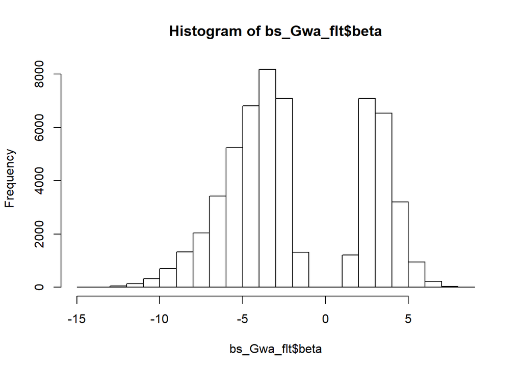

```r
hist(bs_Gwa_flt$beta)
```

```r
# minor allele -> earlier budset (neg. direction)
# look at the subset of alleles with bio effect to look at which pops have sig. minor alleles?

# bedtools intersect

bs_LRT <- ggplot(bs_Gwa_flt, aes(beta, LRTscore)) +
                  geom_point()

# pchisq log.p = T lower.tail = F?

bs_Gwa_flt$p <- -10*(pchisq(bs_Gwa_flt$LRTscore,
                            df = 1, log.p = T, lower.tail = F))
head(bs_Gwa_flt)
```

```
##    Chromosome Position Major Minor Frequency   N LRTscore high_WT.HE.HO LRTem
## 1 MA_10428445     3728     G     C  0.177386 339 0.001016      135/51/0   NaN
## 2 MA_10428445     3740     C     T  0.174603 339 0.417620      117/39/1   NaN
## 3 MA_10428445     3742     A     G  0.164909 339 0.053843      127/25/0   NaN
## 4 MA_10428445     3749     C     T  0.237769 339 0.221072       44/31/1   NaN
## 5 MA_10428445     3763     G     C  0.338875 339 2.086469       15/38/0   NaN
## 6 MA_10428445     3768     C     T  0.143482 339 0.105600       68/11/0   NaN
##   beta  SE emIter          p
## 1  NaN NaN      0  0.2575695
## 2  NaN NaN      0  6.5753487
## 3  NaN NaN      0  2.0272076
## 4  NaN NaN      0  4.4906546
## 5  NaN NaN      0 19.0643521
## 6  NaN NaN      0  2.9408898
```

```r
bs_Gwa_flt$Position2 <- seq(1,nrow(bs_Gwa_flt))

summary(bs_Gwa_flt)
```

```
##        Chromosome        Position      Major      Minor        Frequency
##  MA_108680  :   767   Min.   :     4   A: 73509   A:176140   Min.   :0.01531
##  MA_41436   :   691   1st Qu.:  3553   C:179504   C: 76855   1st Qu.:0.07122
##  MA_37331   :   647   Median : 10633   G:178593   G: 76757   Median :0.12699
##  MA_54326   :   606   Mean   : 16706   T: 74436   T:176290   Mean   :0.15467
##  MA_78490   :   578   3rd Qu.: 23911                         3rd Qu.:0.21029
##  MA_10397575:   521   Max.   :187964                         Max.   :0.49999
##  (Other)    :502232
##        N          LRTscore         high_WT.HE.HO        LRTem
##  Min.   :339   Min.   :-67.7137   329/10/0:  1780   Min.   : 2.8
##  1st Qu.:339   1st Qu.:  0.1373   328/10/0:  1697   1st Qu.: 4.8
##  Median :339   Median :  0.6224   328/11/0:  1328   Median : 6.1
##  Mean   :339   Mean   :  1.5486   327/11/0:  1297   Mean   : 7.5
##  3rd Qu.:339   3rd Qu.:  1.8753   327/10/0:  1288   3rd Qu.: 8.8
##  Max.   :339   Max.   : 57.2010   326/10/0:  1117   Max.   :63.0
##                                   (Other) :497535   NA's   :450153
##       beta              SE             emIter              p
##  Min.   :-14.3    Min.   :0.6      Min.   : 0.0000   Min.   :  0.000
##  1st Qu.: -4.9    1st Qu.:1.1      1st Qu.: 0.0000   1st Qu.:  3.411
##  Median : -3.0    Median :1.4      Median : 0.0000   Median :  8.436
##  Mean   : -1.9    Mean   :1.6      Mean   : 0.6987   Mean   : 13.513
##  3rd Qu.:  2.6    3rd Qu.:1.9      3rd Qu.: 0.0000   3rd Qu.: 17.669
##  Max.   :  8.9    Max.   :8.0      Max.   :40.0000   Max.   :308.663
##  NA's   :450153   NA's   :450153
##    Position2
##  Min.   :     1
##  1st Qu.:126511
##  Median :253022
##  Mean   :253022
##  3rd Qu.:379532
##  Max.   :506042
##
```

```r
# significant SNPs
quantile(bs_Gwa_flt$p,0.9999)
```

```
##   99.99%
## 184.8012
```

```r
# find outliers for the GWASs
bs_outliers <- bs_Gwa_flt %>%
                  filter(p > 184.8012) #184.8012

0.05/506042
```

```
## [1] 9.880603e-08
```

```r
# 70.05
```

**write out files**

```r
bs_out_bed <- bs_outliers[,c(1,2)]
bs_out_bed$PositionEnd <- bs_out_bed$Position

write.table(bs_out_bed, "./bed_files/bs_outliers.bed",
            row.names = F, col.names = F, sep="\t",quote=F)
```

**Create bed tools and annotate**

```bash
/data/popgen/bedtools2/bin/bedtools intersect \
-a /data/project_data/GroupProjects/GWAS_env/bed_files/bs_outliers.bed \
-b /data/project_data/Annotation/Pabies1.0-HC.gtf \
-wb > bs_intersect.bed
```

**Manhattan plot**

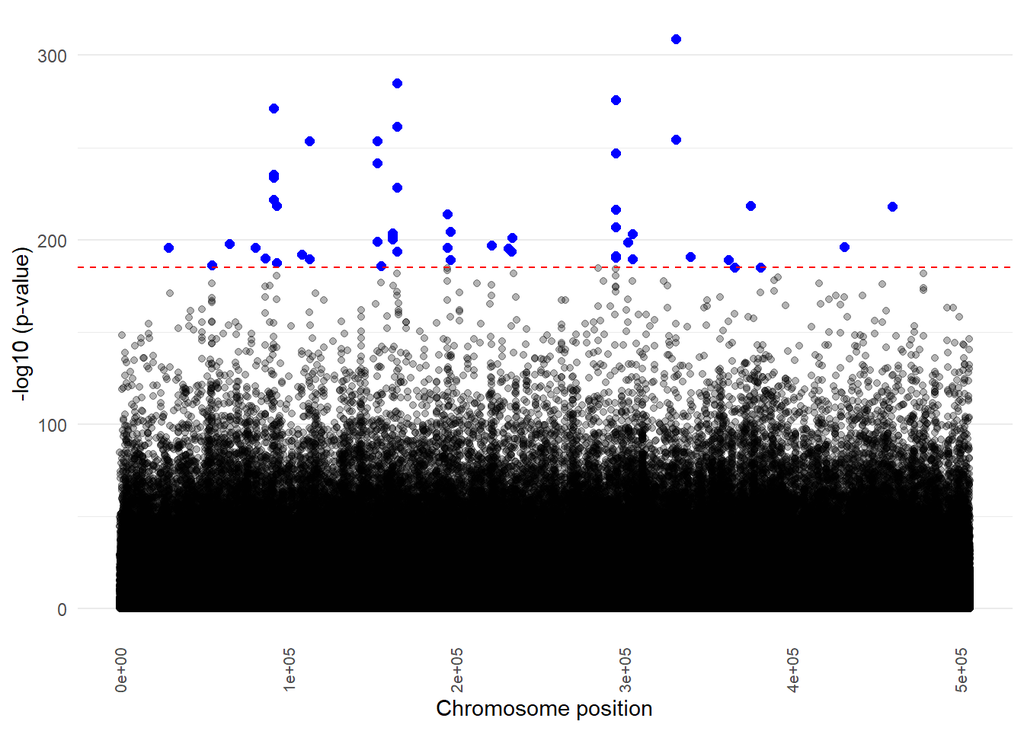

```r
# Manhattan plot

bs_man <- ggplot(bs_Gwa_flt, aes(Position2, p)) +
                  geom_point(alpha=0.3) + theme_minimal() +
                  theme(
                    legend.position = "none",
                    panel.border = element_blank(),
                    panel.grid.major.x = element_blank(),
                    panel.grid.minor.x = element_blank(),
                    axis.text.x = element_text(angle = 90, size = 8, vjust = 0.5)
                  ) + xlab("Chromosome position") + ylab("-log10 (p-value)") +
            geom_point(data=bs_outliers,
                       aes(x=Position2,y=p), color='blue',size=2) +
            geom_hline(yintercept=184.8012, linetype="dashed", color = "red")
bs_man
```

```r
# find intersection with annotations
# venn diagram
# temp and precipitation

# UTR group?
###################################
```

## Height

```r
ht_Gwa <- read.table(gzfile("Z:\\Anoob\\ANGSD\\GWAS\\height2019\\height.lrt0.gz"),
                     header = T)
ht_maf <- read.table(gzfile("Z:\\Anoob\\ANGSD\\GWAS\\height2019\\height.mafs.gz"),
                     header = T)

ht_Gwa_flt <- ht_Gwa %>%
              filter(LRTscore > -998)

summary(ht_Gwa_flt)
```

```
##        Chromosome        Position      Major      Minor        Frequency
##  MA_108680  :   713   Min.   :     4   A: 67891   A:162257   Min.   :0.01672
##  MA_41436   :   641   1st Qu.:  3531   C:165312   C: 71137   1st Qu.:0.07505
##  MA_37331   :   594   Median : 10560   G:164553   G: 70868   Median :0.13173
##  MA_54326   :   547   Mean   : 16645   T: 68775   T:162269   Mean   :0.15873
##  MA_78490   :   536   3rd Qu.: 23834                         3rd Qu.:0.21545
##  MA_10397575:   487   Max.   :160482                         Max.   :0.49999
##  (Other)    :463013
##        N          LRTscore        high_WT.HE.HO        LRTem
##  Min.   :307   Min.   : 0.0000   297/10/0:  1625   Min.   : 2.7
##  1st Qu.:307   1st Qu.: 0.1268   296/10/0:  1524   1st Qu.: 4.6
##  Median :307   Median : 0.5709   295/10/0:  1234   Median : 5.7
##  Mean   :307   Mean   : 1.3386   295/11/0:  1181   Mean   : 6.8
##  3rd Qu.:307   3rd Qu.: 1.6877   296/11/0:  1162   3rd Qu.: 7.8
##  Max.   :307   Max.   :38.1664   294/12/0:   931   Max.   :40.0
##                                  (Other) :458874   NA's   :424832
##       beta              SE             emIter
##  Min.   :-2.6     Min.   :0.2      Min.   : 0.0000
##  1st Qu.:-0.9     1st Qu.:0.3      1st Qu.: 0.0000
##  Median : 0.6     Median :0.4      Median : 0.0000
##  Mean   : 0.2     Mean   :0.4      Mean   : 0.5511
##  3rd Qu.: 1.1     3rd Qu.:0.5      3rd Qu.: 0.0000
##  Max.   : 4.5     Max.   :2.2      Max.   :40.0000
##  NA's   :424832   NA's   :424832
```

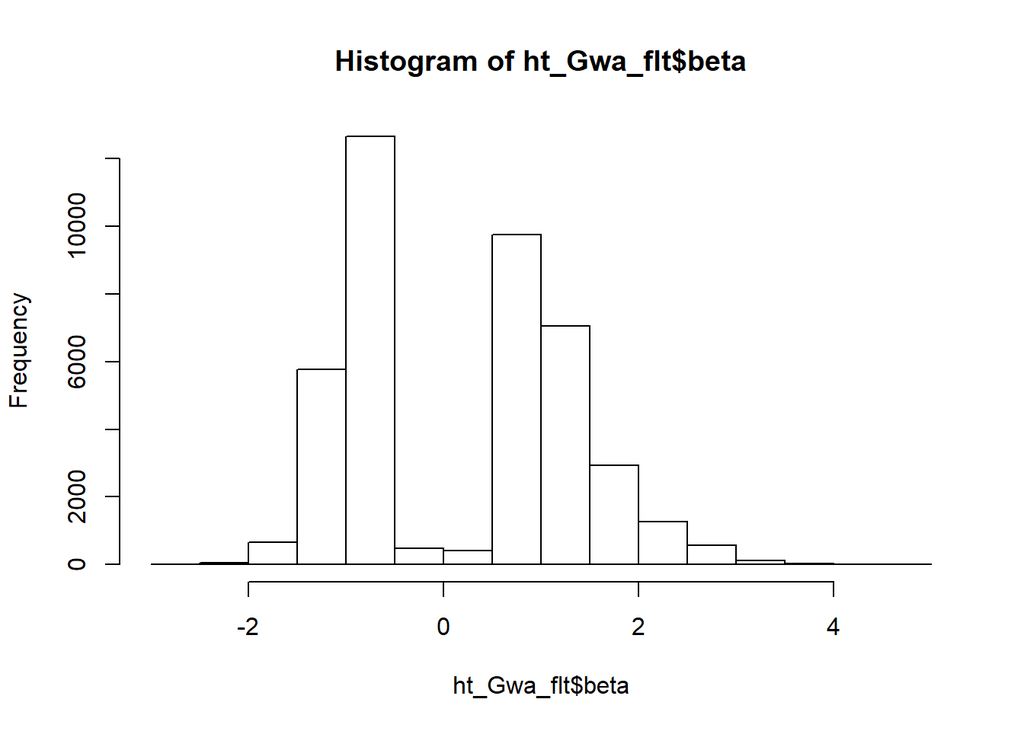

```r
hist(ht_Gwa_flt$beta)
```

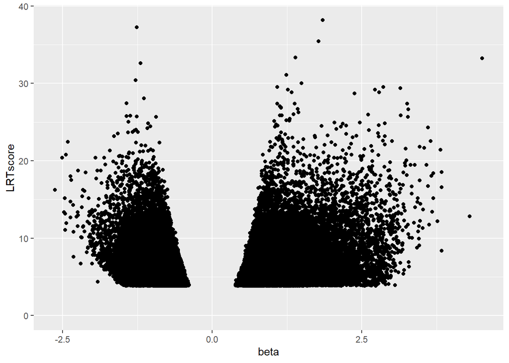

```r
ht_LRT <- ggplot(ht_Gwa_flt, aes(beta, LRTscore)) +
                  geom_point()
ht_LRT
```

```r
# pchisq log.p = T lower.tail = F?

ht_Gwa_flt$p <- -10*(pchisq(ht_Gwa_flt$LRTscore,
                            df = 1,
                            log.p = T,
                            lower.tail = F))
head(ht_Gwa_flt)
```

```
##    Chromosome Position Major Minor Frequency   N LRTscore high_WT.HE.HO
## 1 MA_10428445     3728     G     C  0.168242 307 0.562932      122/43/0
## 2 MA_10428445     3740     C     T  0.179767 307 0.150800      102/35/1
## 3 MA_10428445     3742     A     G  0.170848 307 0.857045      111/22/0
## 4 MA_10428445     3749     C     T  0.250651 307 0.891318       38/27/1
## 5 MA_10428445     3763     G     C  0.304565 307 0.611543       28/36/0
## 6 MA_10428445     3768     C     T  0.146994 307 5.841133       59/10/0
##      LRTem     beta       SE emIter         p
## 1      NaN      NaN      NaN      0  7.916837
## 2      NaN      NaN      NaN      0  3.598628
## 3      NaN      NaN      NaN      0 10.368581
## 4      NaN      NaN      NaN      0 10.638620
## 5      NaN      NaN      NaN      0  8.342329
## 6 8.533869 1.708394 0.309351     32 41.569175
```

```r
ht_Gwa_flt$Position2 <- seq(1,nrow(ht_Gwa_flt))

summary(ht_Gwa_flt)
```

```
##        Chromosome        Position      Major      Minor        Frequency
##  MA_108680  :   713   Min.   :     4   A: 67891   A:162257   Min.   :0.01672
##  MA_41436   :   641   1st Qu.:  3531   C:165312   C: 71137   1st Qu.:0.07505
##  MA_37331   :   594   Median : 10560   G:164553   G: 70868   Median :0.13173
##  MA_54326   :   547   Mean   : 16645   T: 68775   T:162269   Mean   :0.15873
##  MA_78490   :   536   3rd Qu.: 23834                         3rd Qu.:0.21545
##  MA_10397575:   487   Max.   :160482                         Max.   :0.49999
##  (Other)    :463013
##        N          LRTscore        high_WT.HE.HO        LRTem
##  Min.   :307   Min.   : 0.0000   297/10/0:  1625   Min.   : 2.7
##  1st Qu.:307   1st Qu.: 0.1268   296/10/0:  1524   1st Qu.: 4.6
##  Median :307   Median : 0.5709   295/10/0:  1234   Median : 5.7
##  Mean   :307   Mean   : 1.3386   295/11/0:  1181   Mean   : 6.8
##  3rd Qu.:307   3rd Qu.: 1.6877   296/11/0:  1162   3rd Qu.: 7.8
##  Max.   :307   Max.   :38.1664   294/12/0:   931   Max.   :40.0
##                                  (Other) :458874   NA's   :424832
##       beta              SE             emIter              p
##  Min.   :-2.6     Min.   :0.2      Min.   : 0.0000   Min.   :  0.000
##  1st Qu.:-0.9     1st Qu.:0.3      1st Qu.: 0.0000   1st Qu.:  3.261
##  Median : 0.6     Median :0.4      Median : 0.0000   Median :  7.987
##  Mean   : 0.2     Mean   :0.4      Mean   : 0.5511   Mean   : 12.219
##  3rd Qu.: 1.1     3rd Qu.:0.5      3rd Qu.: 0.0000   3rd Qu.: 16.404
##  Max.   : 4.5     Max.   :2.2      Max.   :40.0000   Max.   :211.547
##  NA's   :424832   NA's   :424832
##    Position2
##  Min.   :     1
##  1st Qu.:116634
##  Median :233266
##  Mean   :233266
##  3rd Qu.:349899
##  Max.   :466531
##
```

```r
# significant SNPs
quantile(ht_Gwa_flt$p,0.9999) #142.655
```

```
##   99.99%
## 142.6555
```

```r
# find outliers for the GWASs
ht_outliers <- ht_Gwa_flt %>%
                  filter(p > 142.6555)
```

**write out files**

```r
# ht_out_bed <- ht_outliers[,c(1,2)]
# ht_out_bed$PositionEnd <- ht_out_bed$Position
#
# write.table(ht_out_bed, "./bed_files/ht_outliers.bed",
#             row.names = F, col.names = F, sep="\t",quote=F)
```

**Create bed tools and annotate**

```bash
/data/popgen/bedtools2/bin/bedtools intersect \
-a /data/project_data/GroupProjects/GWAS_env/bed_files/ht_outliers.bed \
-b /data/project_data/Annotation/Pabies1.0-HC.gtf \
-wb > ht_intersect.bed
```

**Manhattan plot**

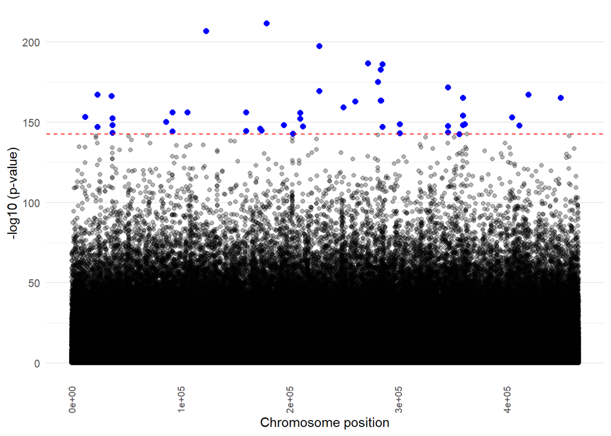

```r
# Manhattan plot

ht_man <- ggplot(ht_Gwa_flt, aes(Position2, p)) +
                  geom_point(alpha=0.3) + theme_minimal() +
                  theme(
                    legend.position = "none",
                    panel.border = element_blank(),
                    panel.grid.major.x = element_blank(),
                    panel.grid.minor.x = element_blank(),
                    axis.text.x = element_text(angle = 90, size = 8, vjust = 0.5)
                  ) + xlab("Chromosome position") + ylab("-log10 (p-value)") +
            geom_point(data=ht_outliers,
                       aes(x=Position2,y=p), color='blue',size=2) +
            geom_hline(yintercept=142.655, linetype="dashed", color = "red")
ht_man
```

## Bio05

```r
bio05_Gwa <- read.table(gzfile("Z:\\Anoob\\ANGSD\\GWAS\\bio05\\bio05.lrt0.gz"),
                     header = T)


bio05_maf <- read.table(gzfile("Z:\\Anoob\\ANGSD\\GWAS\\bio05\\bio05.mafs.gz"),
                     header = T)

bio05_Gwa_flt <- bio05_Gwa %>%
                 filter(LRTscore > -998)

summary(bio05_Gwa_flt)
```

```
##        Chromosome        Position      Major      Minor        Frequency
##  MA_108680  :   770   Min.   :     4   A: 73602   A:176352   Min.   :0.01527
##  MA_41436   :   692   1st Qu.:  3552   C:179752   C: 76944   1st Qu.:0.07112
##  MA_37331   :   647   Median : 10633   G:178834   G: 76839   Median :0.12686
##  MA_54326   :   606   Mean   : 16706   T: 74521   T:176574   Mean   :0.15456
##  MA_78490   :   576   3rd Qu.: 23912                         3rd Qu.:0.21013
##  MA_10397575:   521   Max.   :187964                         Max.   :0.49997
##  (Other)    :502897
##        N          LRTscore        high_WT.HE.HO        LRTem
##  Min.   :340   Min.   : 0.0000   330/10/0:  1770   Min.   : 3.4
##  1st Qu.:340   1st Qu.: 0.1253   329/10/0:  1699   1st Qu.: 4.6
##  Median :340   Median : 0.5662   329/11/0:  1333   Median : 5.7
##  Mean   :340   Mean   : 1.3569   328/11/0:  1301   Mean   : 6.7
##  3rd Qu.:340   3rd Qu.: 1.6856   328/10/0:  1278   3rd Qu.: 7.7
##  Max.   :340   Max.   :36.9755   327/10/0:  1125   Max.   :39.3
##                                  (Other) :498203   NA's   :460995
##       beta              SE             emIter
##  Min.   :-23.3    Min.   : 1.2     Min.   : 0.0000
##  1st Qu.: -5.5    1st Qu.: 2.2     1st Qu.: 0.0000
##  Median :  5.1    Median : 2.8     Median : 0.0000
##  Mean   :  2.1    Mean   : 3.0     Mean   : 0.3711
##  3rd Qu.:  7.9    3rd Qu.: 3.6     3rd Qu.: 0.0000
##  Max.   : 23.5    Max.   :16.1     Max.   :40.0000
##  NA's   :460995   NA's   :460995
```

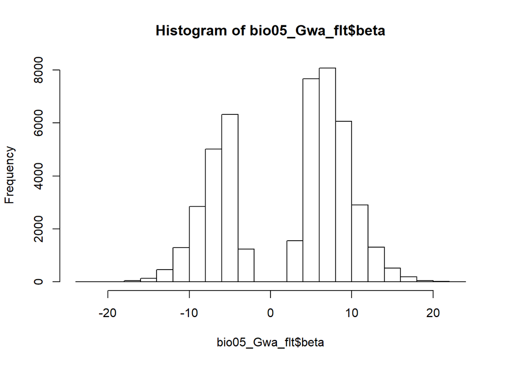

```r
hist(bio05_Gwa_flt$beta)
```

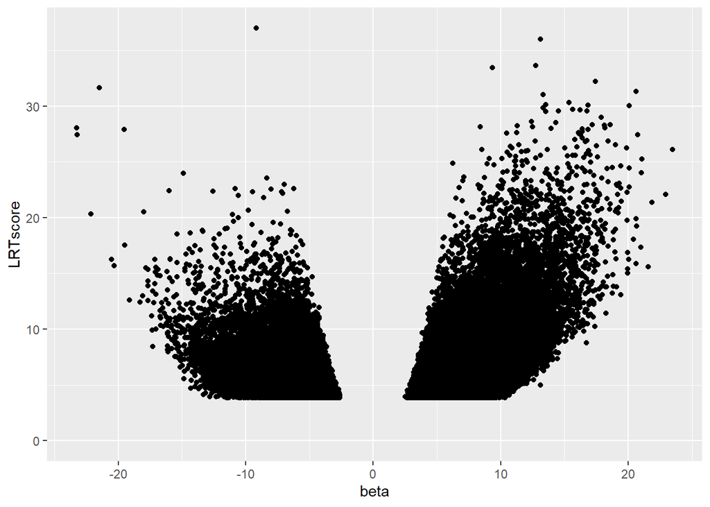

```r
bio05_LRT <- ggplot(bio05_Gwa_flt, aes(beta, LRTscore)) +
                  geom_point()
bio05_LRT
```

```r
# pchisq log.p = T lower.tail = F?

bio05_Gwa_flt$p <- -10*(pchisq(bio05_Gwa_flt$LRTscore,
                            df = 1,
                            log.p = T,
                            lower.tail = F))
head(bio05_Gwa_flt)
```

```
##    Chromosome Position Major Minor Frequency   N LRTscore high_WT.HE.HO
## 1 MA_10428445     3728     G     C  0.177386 340 3.114085      135/51/0
## 2 MA_10428445     3740     C     T  0.174603 340 0.162685      117/39/1
## 3 MA_10428445     3742     A     G  0.164909 340 0.399389      127/25/0
## 4 MA_10428445     3749     C     T  0.240566 340 0.634630       44/31/1
## 5 MA_10428445     3763     G     C  0.337670 340 1.050737       15/38/0
## 6 MA_10428445     3768     C     T  0.142766 340 3.984088       68/11/0
##      LRTem     beta       SE emIter         p
## 1      NaN      NaN      NaN      0 25.559551
## 2      NaN      NaN      NaN      0  3.758630
## 3      NaN      NaN      NaN      0  6.397866
## 4      NaN      NaN      NaN      0  8.541095
## 5      NaN      NaN      NaN      0 11.863379
## 6 4.025433 6.190543 2.778651      2 30.805941
```

```r
bio05_Gwa_flt$Position2 <- seq(1,nrow(bio05_Gwa_flt))

summary(bio05_Gwa_flt)
```

```
##        Chromosome        Position      Major      Minor        Frequency
##  MA_108680  :   770   Min.   :     4   A: 73602   A:176352   Min.   :0.01527
##  MA_41436   :   692   1st Qu.:  3552   C:179752   C: 76944   1st Qu.:0.07112
##  MA_37331   :   647   Median : 10633   G:178834   G: 76839   Median :0.12686
##  MA_54326   :   606   Mean   : 16706   T: 74521   T:176574   Mean   :0.15456
##  MA_78490   :   576   3rd Qu.: 23912                         3rd Qu.:0.21013
##  MA_10397575:   521   Max.   :187964                         Max.   :0.49997
##  (Other)    :502897
##        N          LRTscore        high_WT.HE.HO        LRTem
##  Min.   :340   Min.   : 0.0000   330/10/0:  1770   Min.   : 3.4
##  1st Qu.:340   1st Qu.: 0.1253   329/10/0:  1699   1st Qu.: 4.6
##  Median :340   Median : 0.5662   329/11/0:  1333   Median : 5.7
##  Mean   :340   Mean   : 1.3569   328/11/0:  1301   Mean   : 6.7
##  3rd Qu.:340   3rd Qu.: 1.6856   328/10/0:  1278   3rd Qu.: 7.7
##  Max.   :340   Max.   :36.9755   327/10/0:  1125   Max.   :39.3
##                                  (Other) :498203   NA's   :460995
##       beta              SE             emIter              p
##  Min.   :-23.3    Min.   : 1.2     Min.   : 0.0000   Min.   :  0.000
##  1st Qu.: -5.5    1st Qu.: 2.2     1st Qu.: 0.0000   1st Qu.:  3.238
##  Median :  5.1    Median : 2.8     Median : 0.0000   Median :  7.945
##  Mean   :  2.1    Mean   : 3.0     Mean   : 0.3711   Mean   : 12.311
##  3rd Qu.:  7.9    3rd Qu.: 3.6     3rd Qu.: 0.0000   3rd Qu.: 16.389
##  Max.   : 23.5    Max.   :16.1     Max.   :40.0000   Max.   :205.441
##  NA's   :460995   NA's   :460995
##    Position2
##  Min.   :     1
##  1st Qu.:126678
##  Median :253355
##  Mean   :253355
##  3rd Qu.:380032
##  Max.   :506709
##
```

```r
# significant SNPs
quantile(bio05_Gwa_flt$p,0.9999) #150.7185
```

```
##   99.99%
## 150.7185
```

```r
# find outliers for the GWASs
bio05_outliers <- bio05_Gwa_flt %>%
                  filter(p > 150.7185)
```

**write out files**

```r
# bio05_out_bed <- bio05_outliers[,c(1,2)]
# bio05_out_bed$PositionEnd <- bio05_out_bed$Position
#
# write.table(bio05_out_bed, "./bed_files/bio05_outliers.bed",
#             row.names = F, col.names = F, sep="\t",quote=F)
```

**Create bed tools and annotate**

```bash
/data/popgen/bedtools2/bin/bedtools intersect \
-a /data/project_data/GroupProjects/GWAS_env/bed_files/bio05_outliers.bed \
-b /data/project_data/Annotation/Pabies1.0-HC.gtf \
-wb > bio05_intersect.bed
```

**Manhattan plot**

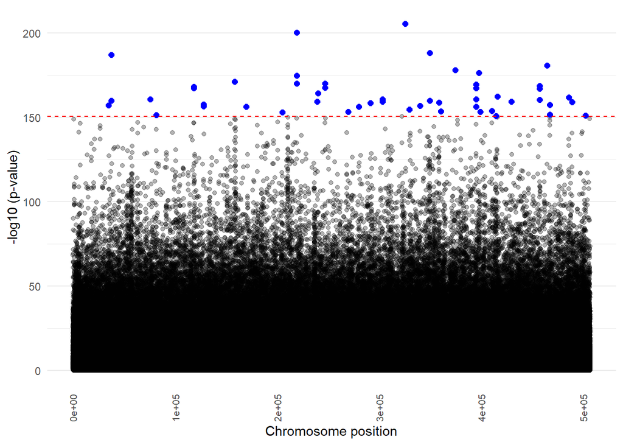

```r
# Manhattan plot

bio05_man <- ggplot(bio05_Gwa_flt, aes(Position2, p)) +
                  geom_point(alpha=0.3) + theme_minimal() +
                  theme(
                    legend.position = "none",
                    panel.border = element_blank(),
                    panel.grid.major.x = element_blank(),
                    panel.grid.minor.x = element_blank(),
                    axis.text.x = element_text(angle = 90, size = 8, vjust = 0.5)
                  ) + xlab("Chromosome position") + ylab("-log10 (p-value)") +
            geom_point(data=bio05_outliers,
                       aes(x=Position2,y=p), color='blue',size=2) +
            geom_hline(yintercept=150.7185, linetype="dashed", color = "red")
bio05_man
```

## Bio18

```r
bio18_Gwa <- read.table(gzfile("Z:\\Anoob\\ANGSD\\GWAS\\bio18\\bio18.lrt0.gz"),
                     header = T)


bio18_maf <- read.table(gzfile("Z:\\Anoob\\ANGSD\\GWAS\\bio18\\bio18.mafs.gz"),
                     header = T)

bio18_Gwa_flt <- bio18_Gwa %>%
                 filter(LRTscore > -998)

summary(bio18_Gwa_flt)
```

```
##        Chromosome        Position      Major      Minor        Frequency
##  MA_108680  :   770   Min.   :     4   A: 73602   A:176352   Min.   :0.01527
##  MA_41436   :   692   1st Qu.:  3552   C:179752   C: 76944   1st Qu.:0.07112
##  MA_37331   :   647   Median : 10633   G:178834   G: 76839   Median :0.12686
##  MA_54326   :   606   Mean   : 16706   T: 74521   T:176574   Mean   :0.15456
##  MA_78490   :   576   3rd Qu.: 23912                         3rd Qu.:0.21013
##  MA_10397575:   521   Max.   :187964                         Max.   :0.49997
##  (Other)    :502897
##        N          LRTscore        high_WT.HE.HO        LRTem
##  Min.   :340   Min.   :-8.1781   330/10/0:  1770   Min.   : 1.3
##  1st Qu.:340   1st Qu.: 0.1338   329/10/0:  1699   1st Qu.: 4.7
##  Median :340   Median : 0.6076   329/11/0:  1333   Median : 5.9
##  Mean   :340   Mean   : 1.4659   328/11/0:  1301   Mean   : 7.3
##  3rd Qu.:340   3rd Qu.: 1.8271   328/10/0:  1278   3rd Qu.: 8.2
##  Max.   :340   Max.   :55.3646   327/10/0:  1125   Max.   :71.1
##                                  (Other) :498203   NA's   :453542
##       beta              SE             emIter
##  Min.   :-56.5    Min.   : 3.9     Min.   : 0.0000
##  1st Qu.:-24.2    1st Qu.: 7.1     1st Qu.: 0.0000
##  Median :-16.2    Median : 9.3     Median : 0.0000
##  Mean   : -2.9    Mean   :11.3     Mean   : 0.6746
##  3rd Qu.: 19.3    3rd Qu.:13.9     3rd Qu.: 0.0000
##  Max.   :121.7    Max.   :79.8     Max.   :40.0000
##  NA's   :453542   NA's   :453542
```

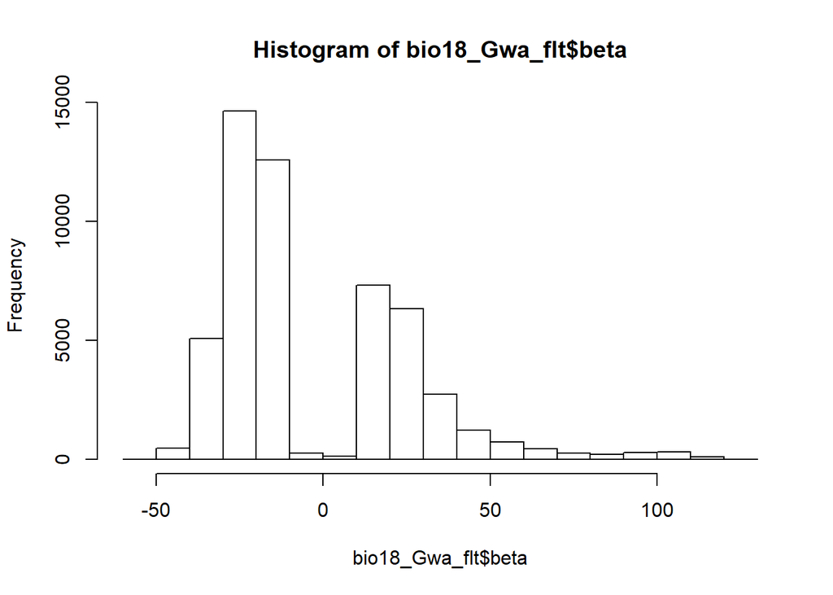

```r
hist(bio18_Gwa_flt$beta)
```

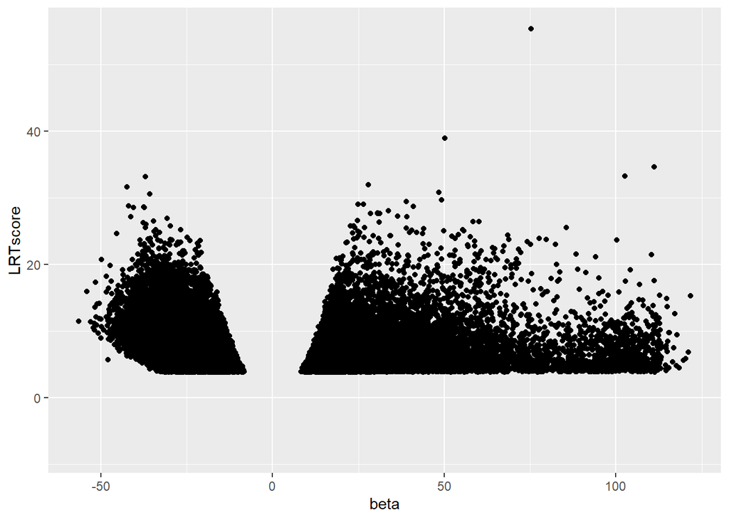

```r
bio18_LRT <- ggplot(bio18_Gwa_flt, aes(beta, LRTscore)) +
                  geom_point()
bio18_LRT
```

```r
# pchisq log.p = T lower.tail = F?

bio18_Gwa_flt$p <- -10*(pchisq(bio18_Gwa_flt$LRTscore,
                            df = 1,
                            log.p = T,
                            lower.tail = F))
head(bio18_Gwa_flt)
```

```
##    Chromosome Position Major Minor Frequency   N  LRTscore high_WT.HE.HO
## 1 MA_10428445     3728     G     C  0.177386 340 11.080536      135/51/0
## 2 MA_10428445     3740     C     T  0.174603 340  0.901968      117/39/1
## 3 MA_10428445     3742     A     G  0.164909 340  0.013237      127/25/0
## 4 MA_10428445     3749     C     T  0.240566 340  1.895230       44/31/1
## 5 MA_10428445     3763     G     C  0.337670 340  2.249432       15/38/0
## 6 MA_10428445     3768     C     T  0.142766 340  2.329662       68/11/0
##      LRTem      beta      SE emIter          p
## 1 10.94625 -22.56209 8.46936      3 70.4427880
## 2      NaN       NaN     NaN      0 10.7220047
## 3      NaN       NaN     NaN      0  0.9606631
## 4      NaN       NaN     NaN      0 17.8014790
## 5      NaN       NaN     NaN      0 20.1243016
## 6      NaN       NaN     NaN      0 20.6412397
```

```r
bio18_Gwa_flt$Position2 <- seq(1,nrow(bio18_Gwa_flt))

summary(bio18_Gwa_flt)
```

```
##        Chromosome        Position      Major      Minor        Frequency
##  MA_108680  :   770   Min.   :     4   A: 73602   A:176352   Min.   :0.01527
##  MA_41436   :   692   1st Qu.:  3552   C:179752   C: 76944   1st Qu.:0.07112
##  MA_37331   :   647   Median : 10633   G:178834   G: 76839   Median :0.12686
##  MA_54326   :   606   Mean   : 16706   T: 74521   T:176574   Mean   :0.15456
##  MA_78490   :   576   3rd Qu.: 23912                         3rd Qu.:0.21013
##  MA_10397575:   521   Max.   :187964                         Max.   :0.49997
##  (Other)    :502897
##        N          LRTscore        high_WT.HE.HO        LRTem
##  Min.   :340   Min.   :-8.1781   330/10/0:  1770   Min.   : 1.3
##  1st Qu.:340   1st Qu.: 0.1338   329/10/0:  1699   1st Qu.: 4.7
##  Median :340   Median : 0.6076   329/11/0:  1333   Median : 5.9
##  Mean   :340   Mean   : 1.4659   328/11/0:  1301   Mean   : 7.3
##  3rd Qu.:340   3rd Qu.: 1.8271   328/10/0:  1278   3rd Qu.: 8.2
##  Max.   :340   Max.   :55.3646   327/10/0:  1125   Max.   :71.1
##                                  (Other) :498203   NA's   :453542
##       beta              SE             emIter              p
##  Min.   :-56.5    Min.   : 3.9     Min.   : 0.0000   Min.   :  0.000
##  1st Qu.:-24.2    1st Qu.: 7.1     1st Qu.: 0.0000   1st Qu.:  3.361
##  Median :-16.2    Median : 9.3     Median : 0.0000   Median :  8.309
##  Mean   : -2.9    Mean   :11.3     Mean   : 0.6746   Mean   : 13.025
##  3rd Qu.: 19.3    3rd Qu.:13.9     3rd Qu.: 0.0000   3rd Qu.: 17.346
##  Max.   :121.7    Max.   :79.8     Max.   :40.0000   Max.   :299.324
##  NA's   :453542   NA's   :453542
##    Position2
##  Min.   :     1
##  1st Qu.:126678
##  Median :253355
##  Mean   :253355
##  3rd Qu.:380032
##  Max.   :506709
##
```

```r
# significant SNPs
quantile(bio18_Gwa_flt$p,0.9999) #143.0102
```

```
##   99.99%
## 143.0102
```

```r
# find outliers for the GWASs
bio18_outliers <- bio18_Gwa_flt %>%
                  filter(p > 143.0102)
```

**write out files**

```r
# bio18_out_bed <- bio18_outliers[,c(1,2)]
# bio18_out_bed$PositionEnd <- bio18_out_bed$Position
#
# write.table(bio18_out_bed, "./bed_files/bio18_outliers.bed",
#             row.names = F, col.names = F, sep="\t",quote=F)
```

**Create bed tools and annotate**

```bash
/data/popgen/bedtools2/bin/bedtools intersect \
-a /data/project_data/GroupProjects/GWAS_env/bed_files/bio18_outliers.bed \
-b /data/project_data/Annotation/Pabies1.0-HC.gtf \
-wb > bio18_intersect.bed
```

**Manhattan plot**

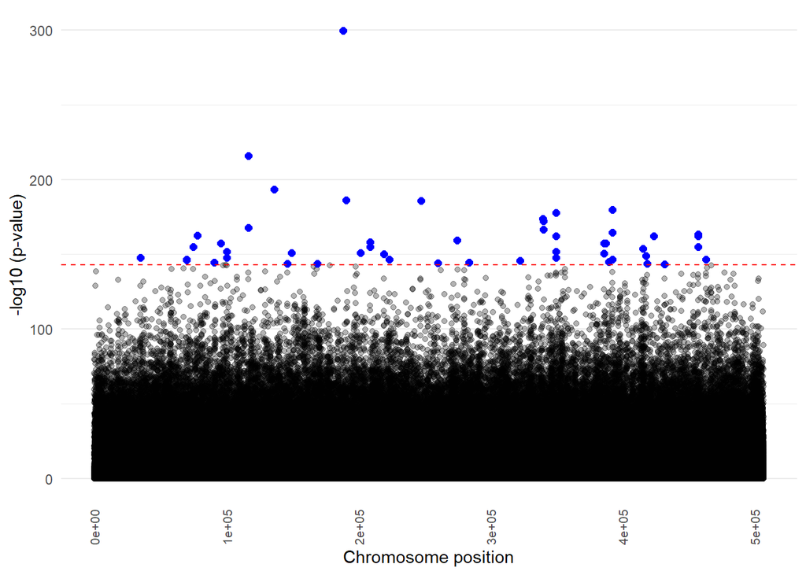

```r
# Manhattan plot

bio18_man <- ggplot(bio18_Gwa_flt, aes(Position2, p)) +
                  geom_point(alpha=0.3) + theme_minimal() +
                  theme(
                    legend.position = "none",
                    panel.border = element_blank(),
                    panel.grid.major.x = element_blank(),
                    panel.grid.minor.x = element_blank(),
                    axis.text.x = element_text(angle = 90, size = 8, vjust = 0.5)
                  ) + xlab("Chromosome position") + ylab("-log10 (p-value)") +
            geom_point(data=bio18_outliers,
                       aes(x=Position2,y=p), color='blue',size=2) +
            geom_hline(yintercept=143.0102, linetype="dashed", color = "red")
bio18_man
```

## tinkering with manhattan plot

```r
require(ggrepel)
```

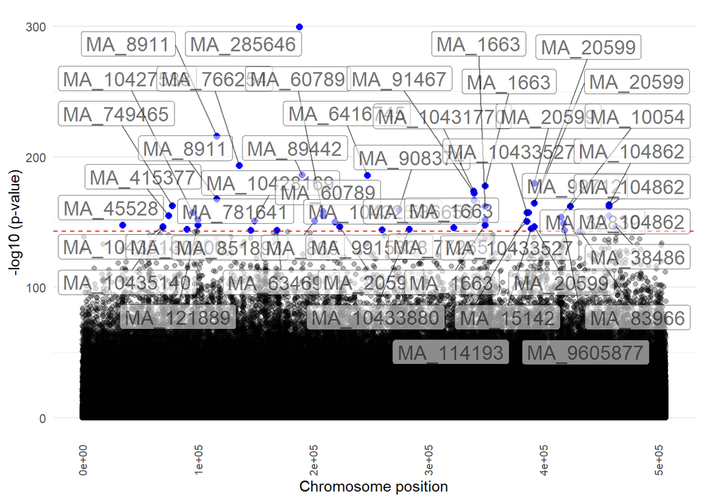

```r
bio18_man1 <- ggplot(bio18_Gwa_flt, aes(Position2, p)) +
                  geom_point(alpha=0.3) + theme_minimal() +
                  theme(
                    legend.position = "none",
                    panel.border = element_blank(),
                    panel.grid.major.x = element_blank(),
                    panel.grid.minor.x = element_blank(),
                    axis.text.x = element_text(angle = 90, size = 8, vjust = 0.5)
                  ) + xlab("Chromosome position") + ylab("-log10 (p-value)") +
            geom_point(data=bio18_outliers,
                       aes(x=Position2,y=p), color='blue',size=2) +
            geom_hline(yintercept=143.0102, linetype="dashed", color = "red") +
            geom_label_repel(data=bio18_outliers,
                             aes(label=as.factor(Chromosome), alpha=0.7), size=5, force=1.3)
bio18_man1
```